# SeriesTemporales

# Casos de las prácticas

## AirBCN

Los datos provienen del sitio web del Ministerio de Obras Públicas de España (www.fomento.es) en el apartado Información estadística / Boletín en línea / Aviación civil / 4.2 Tráfico por aeropuertos. Barcelona y corresponde a la cantidad de pasajeros mensuales de vuelos internacionales en El Prat (BCN).

http://www.fomento.gob.es/BE/?nivel=2&orden=03000000

```r
serie=ts(read.table("airbcn.dat")[,1]/1000,start=1990,freq=12)
```

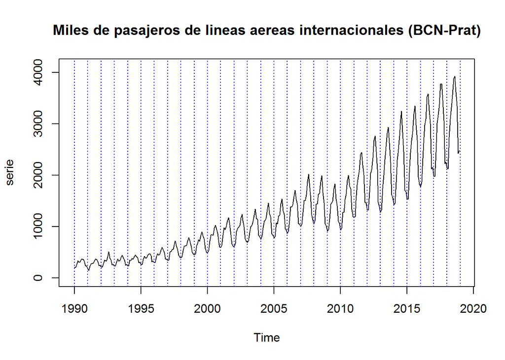

```r
plot(serie,main="Miles de pasajeros de lineas aereas internacionales (BCN-Prat)",ylim=c(0,4100))
abline(v=1990:2019,col=4,lty=3)
```

## Atur

Los datos provienen de la web del Ministerio de Empleo y Seguridad Social de España (http://www.empleo.gob.es/index.htm) en el apartado Estadísticas / Mercado de Trabajo / Movimiento Laboral Registrado / Principales Series y corresponden al número de individuos registrados como parados en las oficinas del INEM.

https://expinterweb.empleo.gob.es/series/

```r
serie=ts(read.table("atur.dat", header=F)/1000,start=1996,freq=12)
```

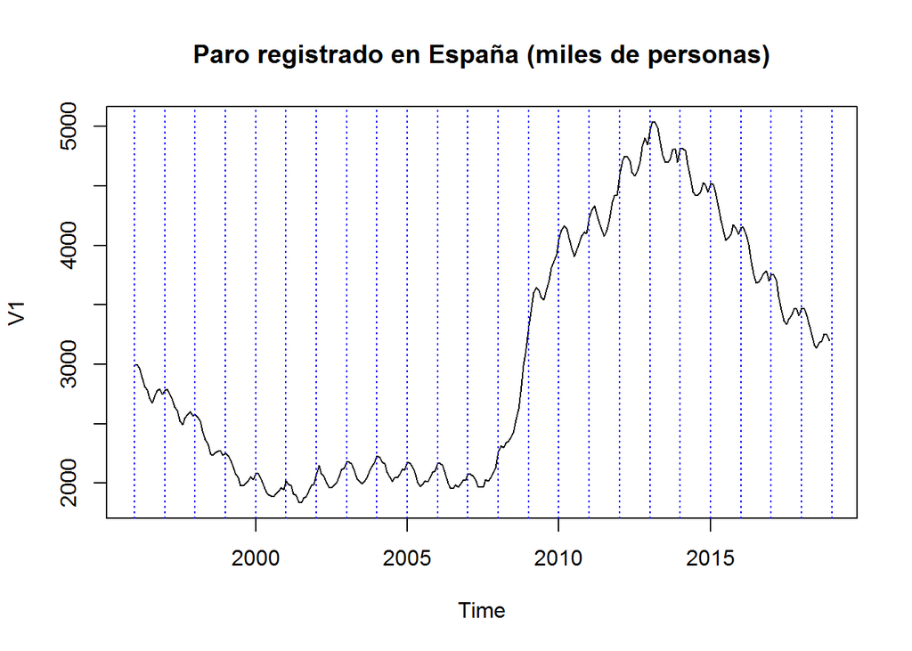

```r
plot(serie,main="Paro registrado en España (miles de personas)")
abline(v=1990:2019,col=4,lty=3)
```

## EURIBOR

Los datos provienen de la web del Instituto Nacional de Estadística de España (www.ine.es) en el apartado Economia / Estadísticas Financieras y Monetarias / Tipos de Interés / Principales Resultados / Tipos de interés legales, del mercado hipotecario y del mercado financiero y corresponden al ínterés hipotecario fijado por el mercado interbancario mediante el índice EURIBOR. La fuente de información es el Banco de España, a través del Boletín Mensual de Estadística del INE.

```r
serie=ts((read.table("euribor.dat")),start=1999,freq=12)
```

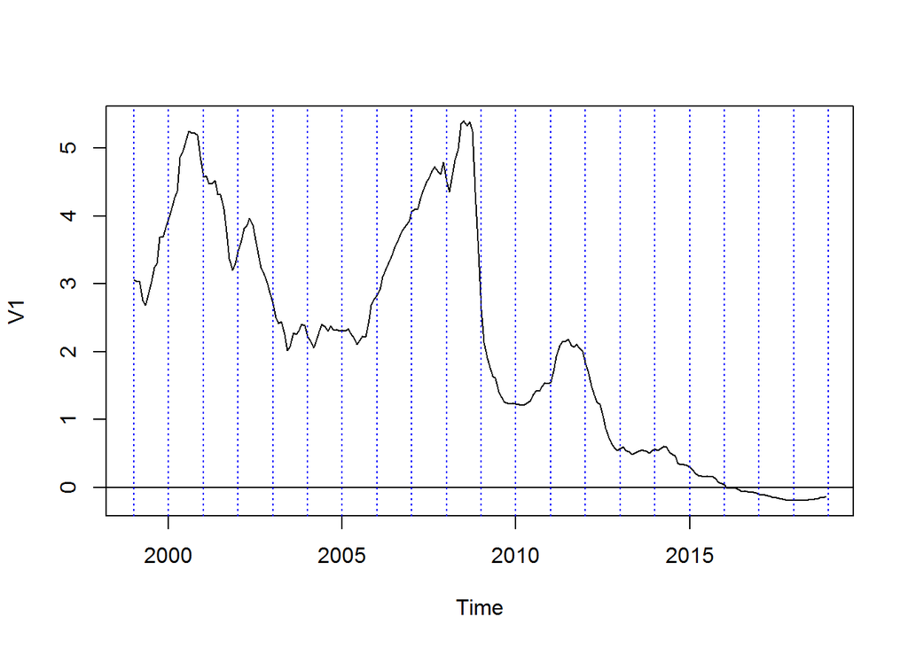

```r
plot(serie)
abline(h=0)
abline(v=1995:2019,col=4,lty=3)
```

## EURODOL

Los datos provienen de la web del Instituto Nacional de Estadística de Espa~na (www.ine.es) en el apartado Economia/ Comercio Exterior / Tipos de Cambio / Principales Resultados y corresponden al tipo de cambio mediomensual de Euro (ECU antes del 1999) respecto al Dólar. La fuente de información es el Banco de España, a través del Boletín Mensual de Estadística del INE.

(Actualización: https://www.bde.es/webbde/es/estadis/infoest/tipos/tipos.html)

```r
serie=ts((read.table("eurodol.dat")),start=1995,freq=12)
```

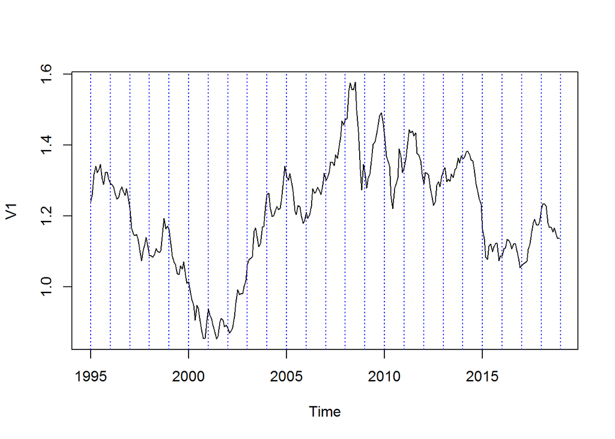

```r
plot(serie)
abline(v=1995:2019,col=4,lty=3)
```

## GDPUSA

Los datos provienen de la web oficial (http://www.bea.gov/national/index.htm) y corresponden al producto interior bruto (GDP-Gross Domestic Product) de los Estados Unidos. Son datos trimestrales que representan el volumen encadenado en dólares (2009) en miles de millones y están corregidos de estacionalidad

```r
serie=ts((read.table("gdpusa.dat")),start=1947,freq=4)
```

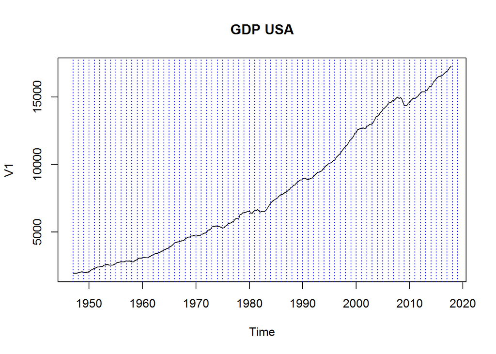

```r
plot(serie,main="GDP USA")
abline(v=1947:2019,col=4,lty=3)
```

## GDPUSAvar

Los datos provienen de la web oficial (http://www.bea.gov/national/index.htm) y corresponden a la variación porcentual respecto al periodo anterior del producto interior bruto (GDP) de los Estados Unidos, basado en precios encadenados. La serie está ajustada estacionalmente.

```r
serie=ts((read.table("gdpUSAvar.dat",header=F)),start=1990,freq=4)
```

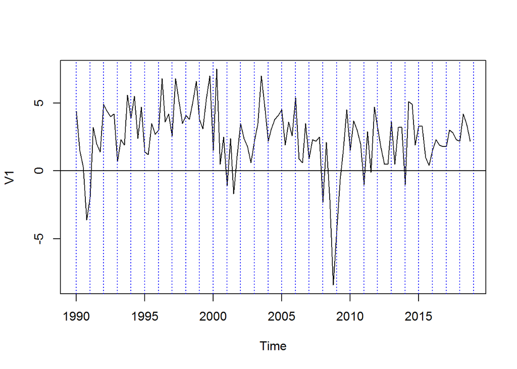

```r
plot(serie)
abline(v=1990:2019,col=4,lty=3)
abline(h=0)
```

## PIBsp

Los datos provienen de la web del Instituto Nacional de Estadística de España (www.ine.es) en el apartado Economia / Cuentas Económicas / Contabilidad Nacional Trimestral de España. Base 2010 / CNTR Base 2010. Series desde el trimestre 1/1995 hasta el último trimestre publicado / PIB pm. Oferta (Indices de volumen encadenados) / Datos corregidos de efectos estacionales y de calendario y corresponden al los datos trimestrales del índice de Producto Interior Bruto en España. La fuente de información es el Banco de España, a través del Boletín Mensual de Estadística del INE.

```r
serie=ts((read.table("pibsp.dat")),start=1995,freq=4)
```

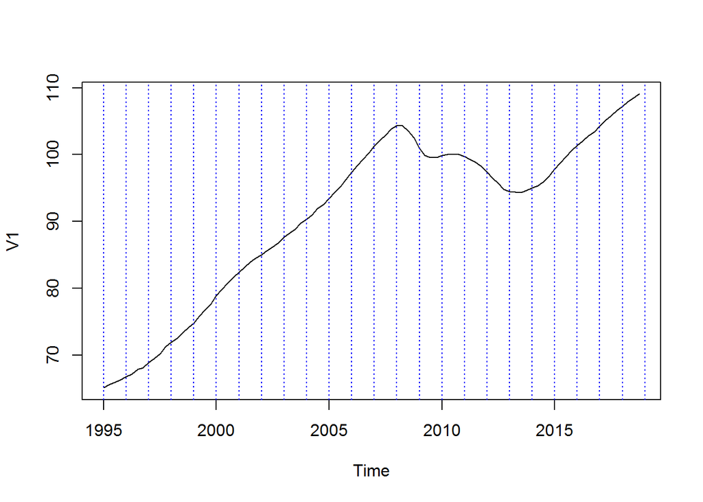

```r
plot(serie)
abline(v=1995:2019,col=4,lty=3)
```

## PreuIndEner

Industrial Energy prices

```r
serie=ts(read.table("preuIndEner.dat"),start=2000,freq=12)
```

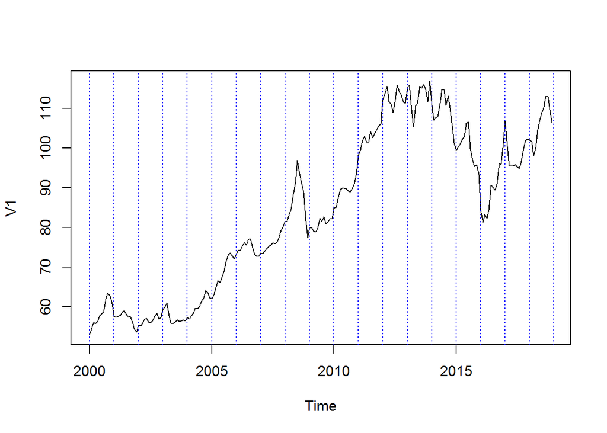

```r
plot(serie)
abline(v=1995:2019,col=4,lty=3)
```

# Casos propuestos para proyectos

## APB

http://www.fomento.gob.es/BE/?nivel=2&orden=04000000

```r
serie=ts(read.table("apb.dat")[,1]/1000,start=1997,freq=12)
```

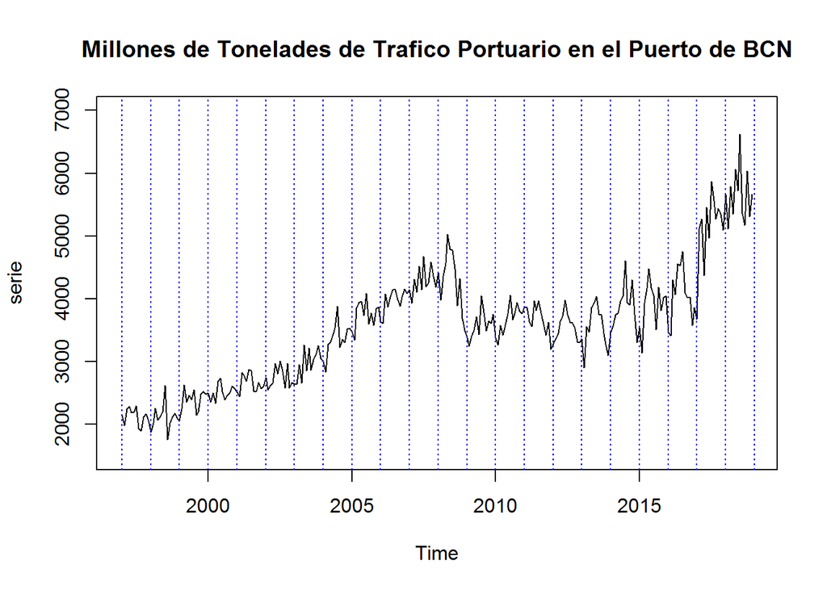

```r
plot(serie,main="Millones de Tonelades de Trafico Portuario en el Puerto de BCN",ylim=c(1500,7000))
abline(v=1996:2019,col=4,lty=3)
```

## CEMENTO

Consumo aparente de cemento en España (Indicador Construcción)

https://apps.fomento.gob.es/Boletinonline/?nivel=2&orden=17000000

```r
serie=window(ts(read.table("cemento.dat"),start=1988,freq=12),start=1990)
```

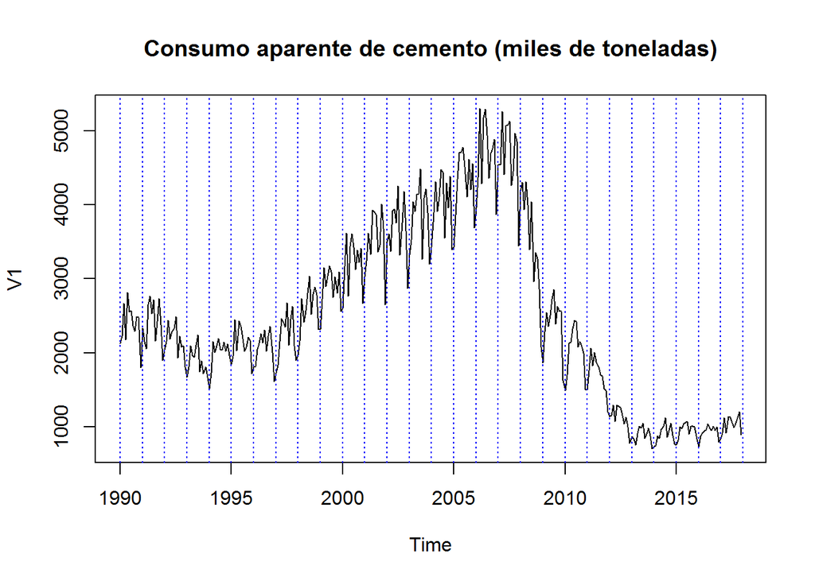

```r
plot(serie,main="Consumo aparente de cemento (miles de toneladas)")
abline(v=1990:2018,col=4,lty=3)
```

## CO2IndUSA

Emisiones de CO2 del sector industrial en USA (Millones de Tm)

**Fuente**: US Energy Information Administration. https://www.eia.gov/totalenergy/data/monthly/ Environment / Industrial Sector

```r
serie=ts(read.table("co2IndUSA.dat"),start=1990,freq=12)
```

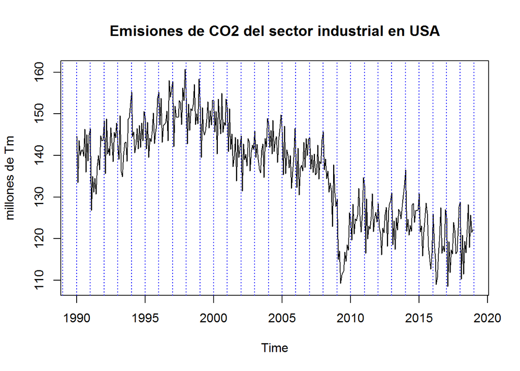

```r
plot(serie,main="Emisiones de CO2 del sector industrial en USA", ylab="millones de Tm")
abline(v=1985:2019,lty=3,col=4)
```

## ConsumElec

Consumo bruto interior de energía eléctrica mensual (Gigawatios-hora) en España.

**Fuente**: Banco de España. https://sedeaplicaciones.minetur.gob.es/Badase/BadasiUI/lstSeriesInformesPostBack.aspx U437ES Consumo de Electricidad en España

```r
serie=ts(read.table("ConsumElec.dat"),start=1990,freq=12)
```

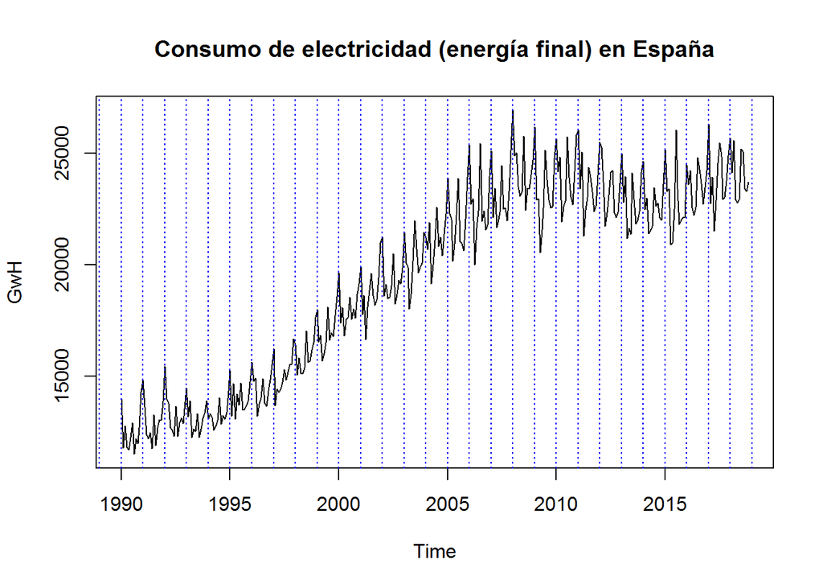

```r
plot(serie, main="Consumo de electricidad (energía final) en España", ylab="GwH")
abline(v=1985:2019,lty=3,col=4)
```

## EnerUSA

Los datos provienen de la U.S. Energy Information Administration (http://www.eia.gov/beta/MER/) y corresponden al consumo global de energía primaria mensual en los Estados Unidos en miles de millones de Btu (British Thermal Units)

https://www.eia.gov/totalenergy/data/browser/index.php?tbl=T02.01#/?f=M&start=200001

```r
serie=ts(read.table("enerusa.dat"),start=1990,freq=12)
```

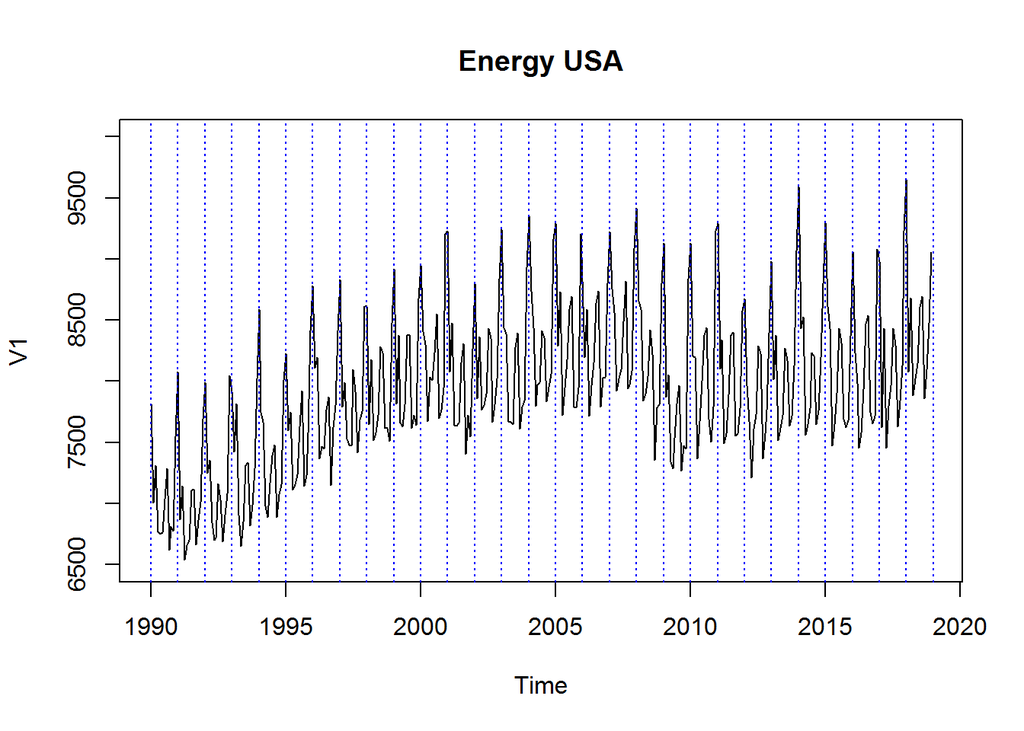

```r
plot(serie,main="Energy USA",ylim=c(6500,10000))
abline(v=1990:2019,col=4,lty=3)
```

## EntradTur

Entrada de turistas en España (millones)

**Fuente**: Ministerio de Industria, Comercio y Turismo. https://sedeaplicaciones.minetur.gob.es/Badase/BadasiUI/lstSeriesInformesPostBack.aspx U64A2: FRONTUR ENTRADA DE TURISTAS

```r
serie=ts(read.table("entradTur.dat")/1000000,start=2000,freq=12)
```

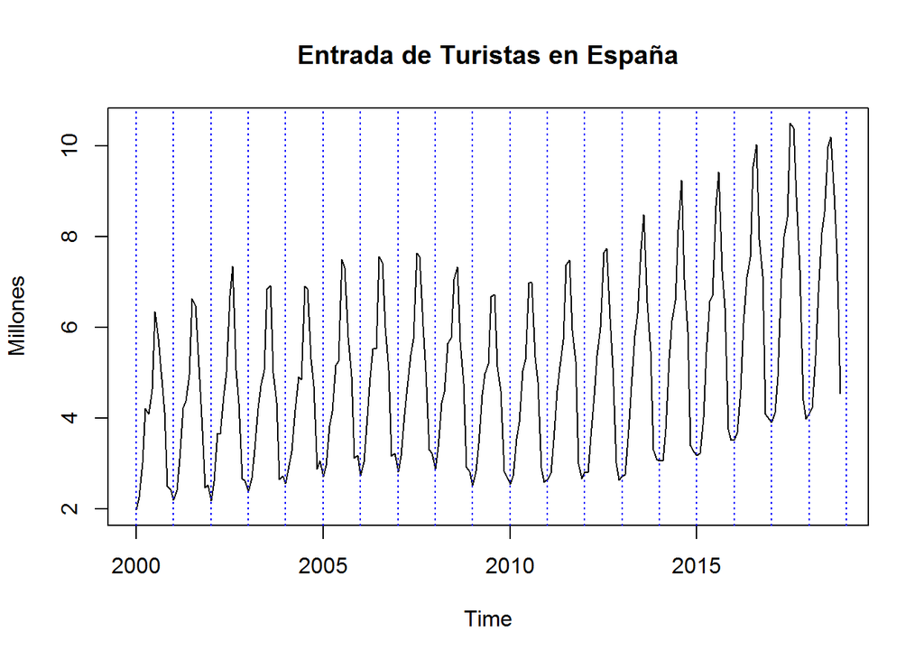

```r
plot(serie,main="Entrada de Turistas en España",ylab="Millones")
abline(v=1999:2019,col=4,lty=3)
```

## EXPORT

Total de exportaciones en miles de millones de euros en España.

Fuente: https://sedeaplicaciones.minetur.gob.es/Badase/BadasiUI/lstSeriesInformesPostBack.aspx Serie: U12XES ESPAÑA. TOTAL EXPORTACIONES ( MILLONES DE EUROS. PRECIOS CORRIENTES, DATOS BRUTOS )

```r
serie=ts(read.table("export.dat")/1000,start=1999,freq=12)
```

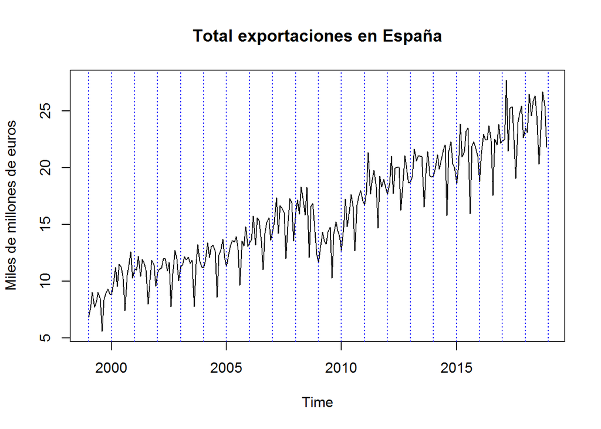

```r
plot(serie,main="Total exportaciones en España",ylab="Miles de millones de euros")
abline(v=1999:2019,col=4,lty=3)
```

## Gasolina

Consumo de Gasolina en España (Miles de toneladas)

**Fuente**: Ministerio de Fomento. http://www.fomento.gob.es Ministerio de Fomento / Información Estadística / Transporte / Indicadores del transporte

http://www.fomento.gob.es/BE/?nivel=2&orden=18000000

```r
serie=ts(read.table("gasolina.dat"),start=1993,freq=12)
```

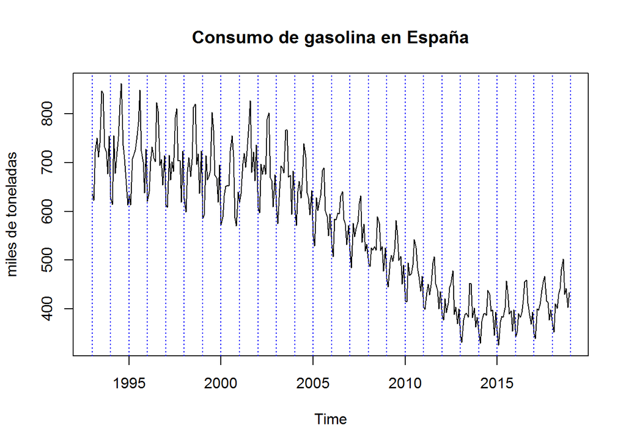

```r
plot(serie, main="Consumo de gasolina en España", ylab="miles de toneladas")
abline(v=1993:2019,lty=3,col=4)
```

## Gripe

Número de casos notificados de afectados de gripe (miles). Datos Mensuales.

**Fuente**: Instituto de Salud Carlos III www.ine.es Sociedad / Salud / Enfermedades de Declaración Obligatoria / Gripe (no activo)

```r
serie=ts(read.table("gripe.dat")/1000,start=1996,freq=12)
```

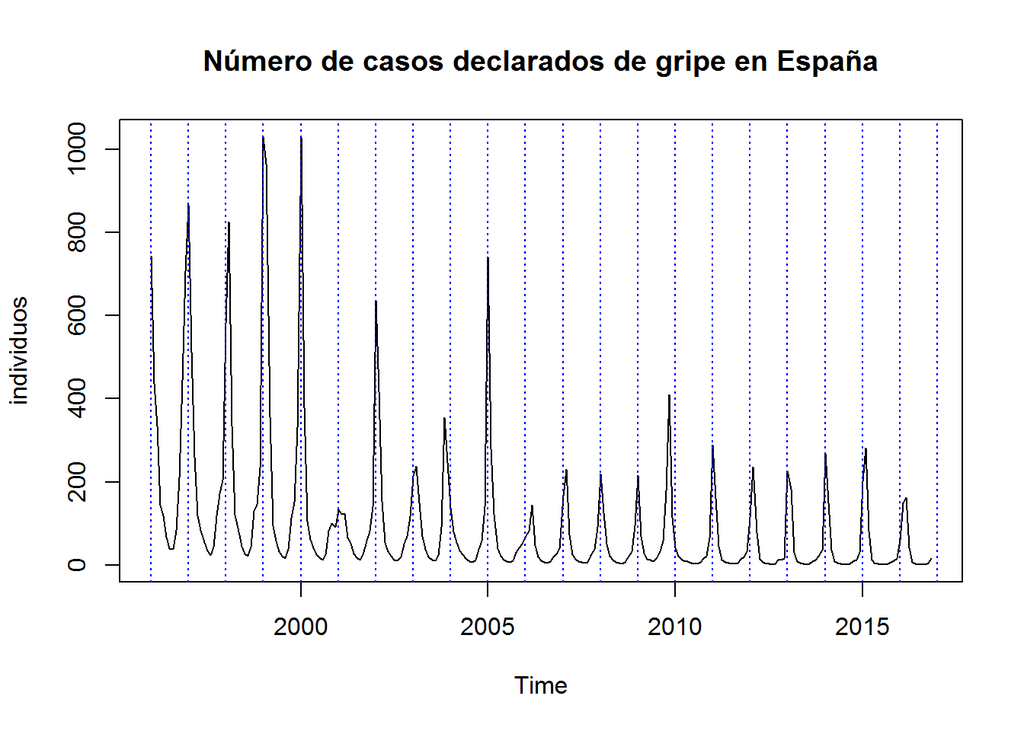

```r
plot(serie, main="Número de casos declarados de gripe en España",ylab="individuos")
abline(v=1996:2018,lty=3,col=4)
```

## IPC

Índice de Precios al Consumo en España (Base 2016).

**Fuente**: Ministerio de Economía y Competitividad. www.ine.es Sociedad / Nivel, calidad y condiciones de vida / Índice de precios de consumo. Base 2016 / Series Mensuales / Índices nacionales: general y de grupos COICOP.

```r
serie=ts(read.table("IPC.dat"),start=2002,freq=12)
```

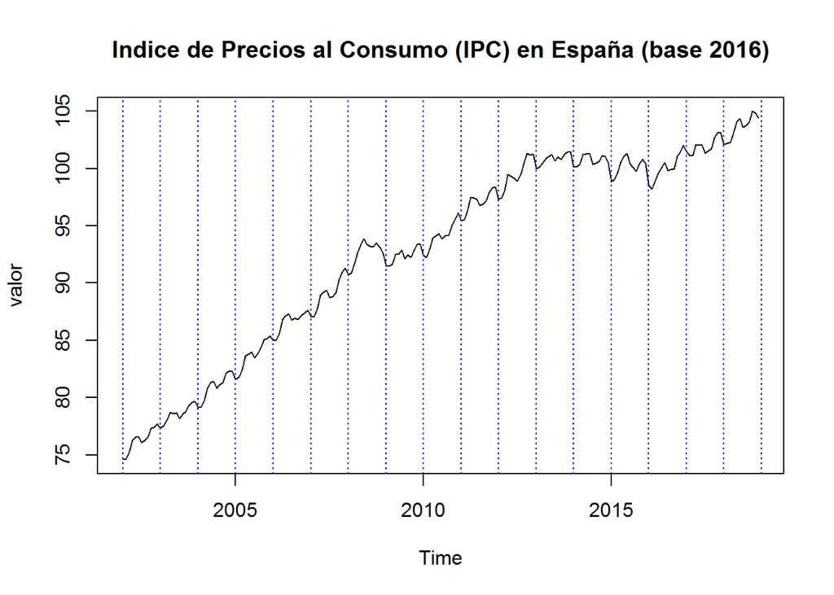

```r
plot(serie, main="Indice de Precios al Consumo (IPC) en España (base 2016)", ylab="valor")
abline(v=2002:2019,lty=3,col=4)
```

## IPI

**Fuente**: Instituto Nacional de Estadística. www.ine.es Industria, energía y construcción / Industria / Índices de Producción Industrial. Base 2010 / General y por destino económico de los bienes. Nacional

```r
serie=ts(read.table("ipi.dat"),start=1990,freq=12)
```

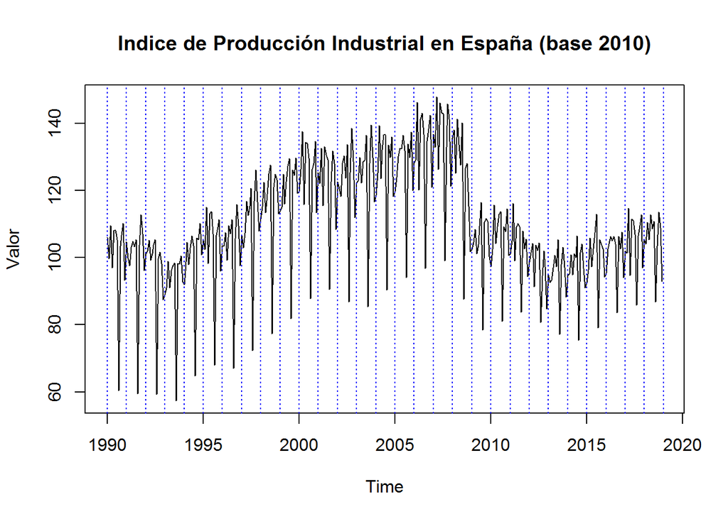

```r
plot(serie,main="Indice de Producción Industrial en España (base 2010)", ylab="Valor")
abline(v=1990:2019,lty=3,col=4)
```

## Metro

Viajeros del metro de Barcelona (miles de viajeros). Datos Mensuales.

**Fuente**: Ministerio de Fomento www.ine.es Servicios / Transporte y actividades conexas, comunicaciones / Estadísticas de Transporte de Viajeros / Series Mensuales / Transporte Urbano / Total metropolitano -Barcelona

http://www.ine.es/jaxiT3/Tabla.htm?t=20193

```r
serie=ts(read.table("metro.dat"),start=1996,freq=12)
```

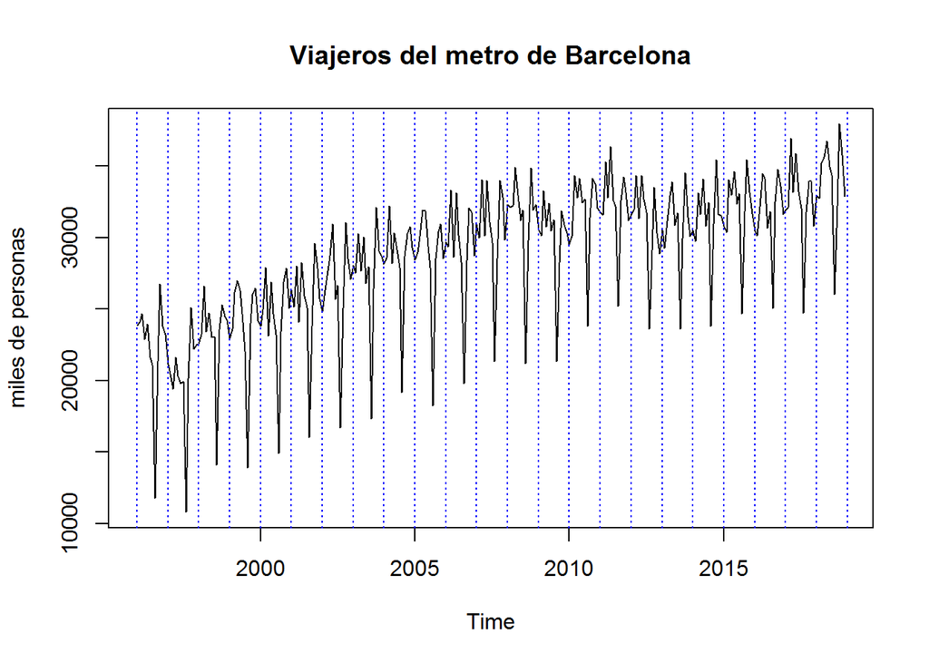

```r
plot(serie,main="Viajeros del metro de Barcelona",ylab="miles de personas")
abline(v=1996:2019,lty=3,col=4)
```

## NUCLEAR

NUCLEAR: Generación de energía eléctrica en centrales nucleares en USA. Datos Mensuales. Fuente: US Energy Information Administration. http://www.eia.gov/totalenergy/data/monthly/#nuclear

```r
serie=ts(read.table("nuclear.dat"),start=1990,freq=12)
```

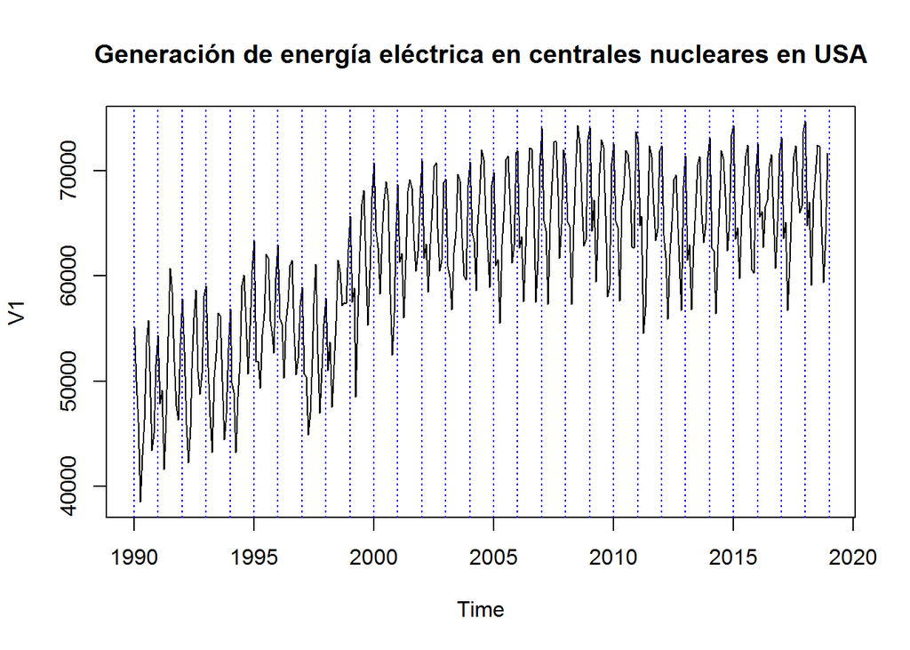

```r
plot(serie,main="Generación de energía eléctrica en centrales nucleares en USA")
abline(v=1990:2019,col=4,lty=3)
```

## PasajeBCN

Miles de pasajeros mensuales en el puerto de Barcelona.

**Fuente**: Ministerio de Fomento. http://www.fomento.gob.es Ministerio de Fomento / Información Estadística / Transporte / Transporte Marítimo

http://www.fomento.gob.es/BE/?nivel=2&orden=04000000

```r
serie=ts(read.table("pasajebcn.dat"),start=1997,freq=12)
```

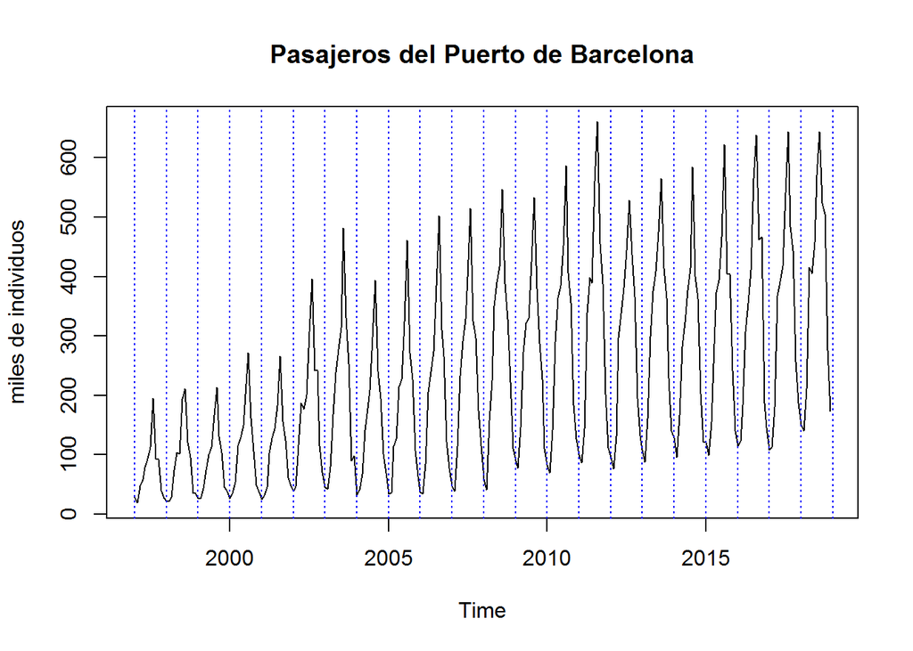

```r
plot(serie, main="Pasajeros del Puerto de Barcelona", ylab="miles de individuos")
abline(v=1997:2019,lty=3,col=4)
```

## Peajes

Intensidad Media Diaria (Número medio de vehículos diario en miles) de tráfico en autopistas en España.

**Fuente**: Ministerio de Fomento. http://www.fomento.gob.es Ministerio de Fomento / Información Estadística / Transporte / Tráfico en autopistas estatales de peaje

http://www.fomento.gob.es/BE/?nivel=2&orden=06000000

```r
serie=ts(read.table("peajes.dat"),start=1990,freq=12)
```

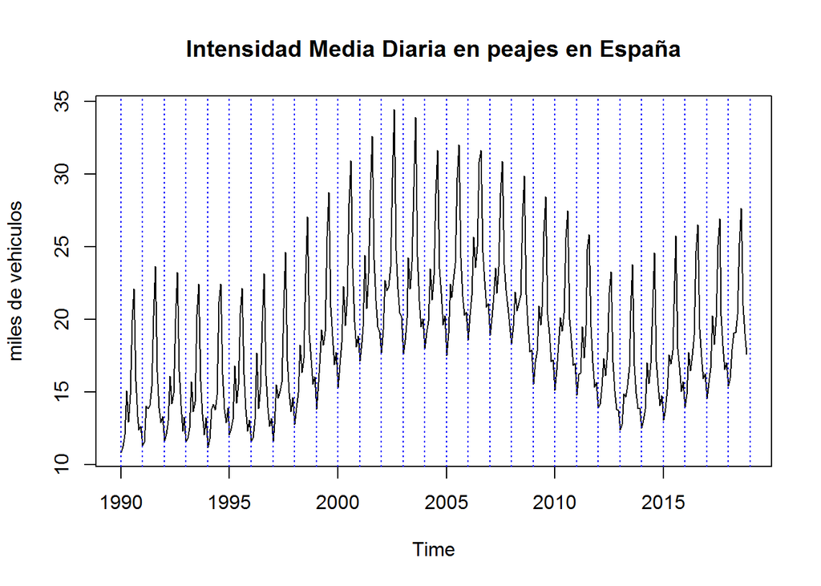

```r
plot(serie, main="Intensidad Media Diaria en peajes en España", ylab="miles de vehiculos")
abline(v=1990:2019,lty=3,col=4)
```

## Pernoct

Número de pernoctaciones en hoteles en España (millones)

**Fuente**: Ministerio de Industria, Comercio y Turismo. https://sedeaplicaciones.minetur.gob.es/Badase/BadasiUI/lstSeriesInformesPostBack.aspx U66B1: EOH. NÚMERO DE PERNOCTACIONES EN HOTELES

```r
serie=ts(read.table("Pernoct.dat")/1000000,start=1999,freq=12)
```

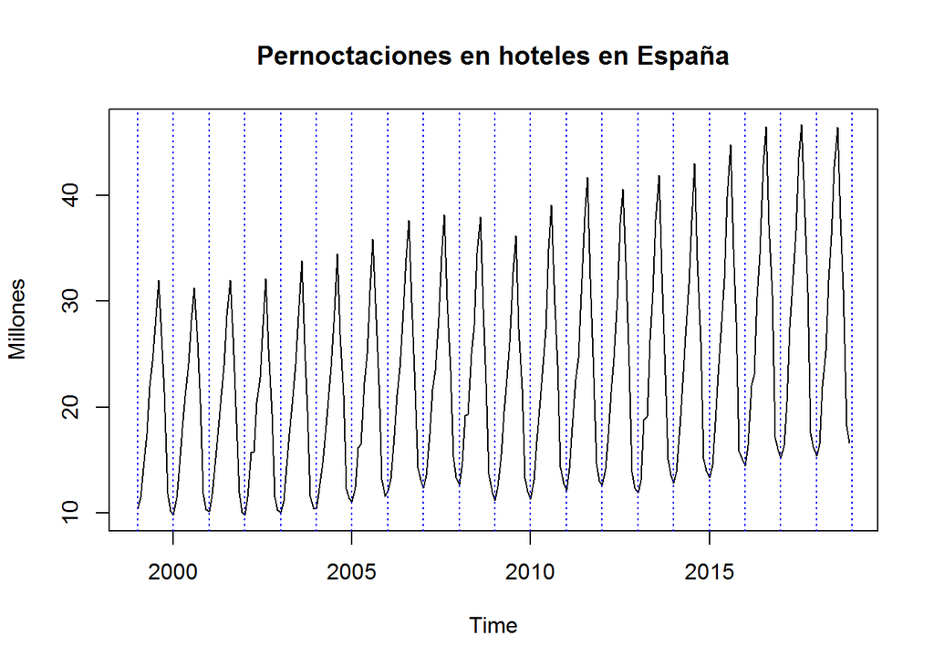

```r
plot(serie,main="Pernoctaciones en hoteles en España",ylab="Millones")
abline(v=1998:2019,col=4,lty=3)
```

## OilStockUSA

```r
serie=ts(read.table("OilStockUSA.dat"),start=1990,freq=12)
```

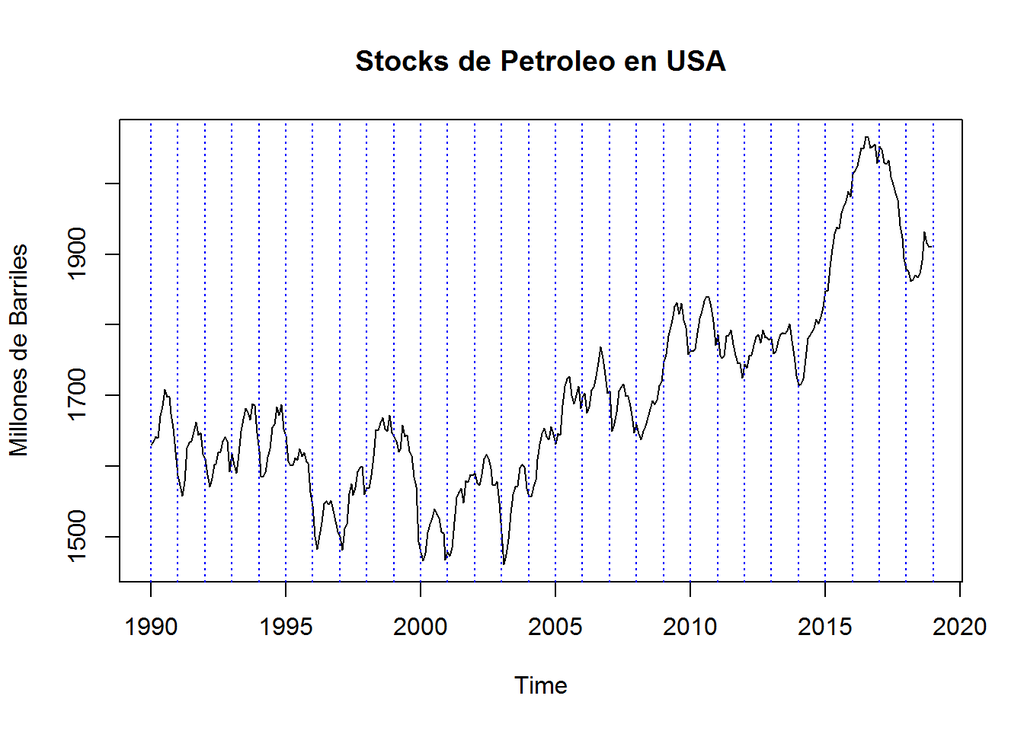

```r
plot(serie,main="Stocks de Petroleo en USA",ylab="Millones de Barriles")
abline(v=1990:2019,col=4,lty=3)
```

## RenewUSA

Los datos provienen de la U.S. Energy Information Administration (http://www.eia.gov/beta/MER/) y corresponden a la producción total de Energía de tipo renovable en trillones de BTU (British Thermal Units)

https://www.eia.gov/totalenergy/data/browser/index.php?tbl=T10.01#/?f=M&start=199001&end=201901&charted=6-7-8-9-14

```r
serie=ts(read.table("RenewUSA.dat", header=F),start=1990,freq=12)
```

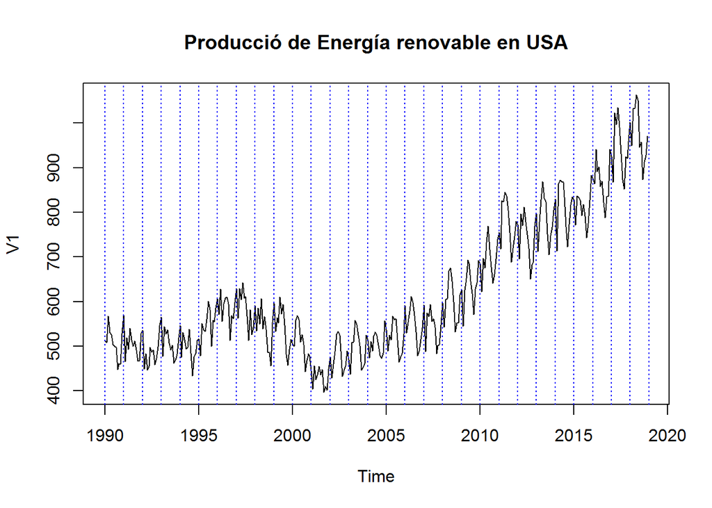

```r
plot(serie,main="Producció de Energía renovable en USA")
abline(v=1990:2019,col=4,lty=3)
```

## TURISMOS

Los datos provienen de la web del Ministerio de Industria,energía y Turismo de España (www.minetur.gob.es) en el apartado Estadísticas e informes Industria Estadística de Fabricación de Vehículos y corresponden al número de turismos (en miles de unidades) fabricados mensualmente en España.

http://www.minetad.gob.es/es-ES/IndicadoresyEstadisticas/Paginas/Estadisticas.aspx

Serie: U3411: EFVYB. TOTAL TURISMOS+TODOTERRENOS. UNIDADES

```r
serie=ts(read.table("turismos.dat")/1000,start=1994,freq=12)
```

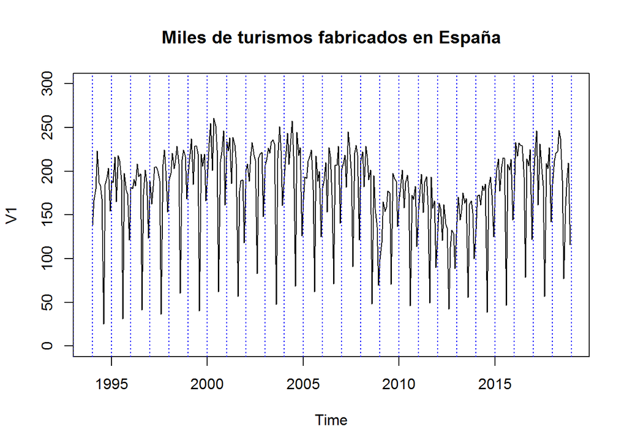

```r
plot(serie,main="Miles de turismos fabricados en España",ylim=c(0,300))
abline(v=1990:2019,col=4,lty=3)
```

## TurMatric

Número de turismos matriculados en España. Datos Mensuales

**Fuente**: Ministerio de Fomento http://www.fomento.gob.es Ministerio de Fomento / Información Estadística / Transporte /Indicadores económicos del transporte

http://www.fomento.gob.es/BE/?nivel=2&orden=18000000

```r
serie=ts(read.table("turmatric.dat"),start=1990,freq=12)
```

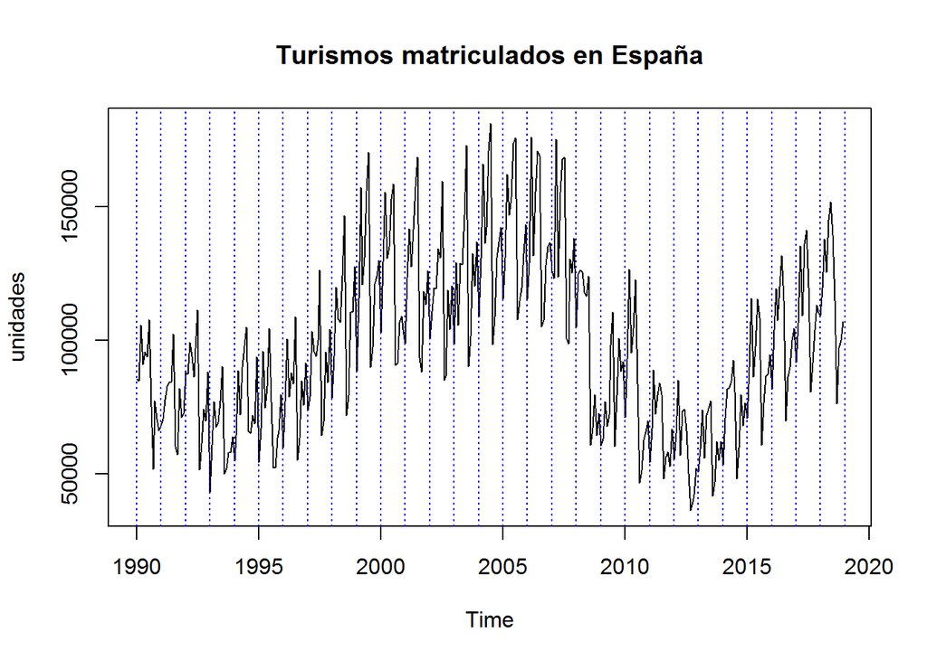

```r
plot(serie, main="Turismos matriculados en España",ylab="unidades")
abline(v=1990:2019,lty=3,col=4)
```

## Varicela

Número de casos de varicela (Enfermedades de declaración obligatoria)

Fuente: #http://www.ine.es/jaxi/Tabla.htm?path=/t38/p604/a2000/l0/&file=0300001.px&L=0

```r
serie=ts(read.table("varicela.dat"),start=1996,freq=12)
```

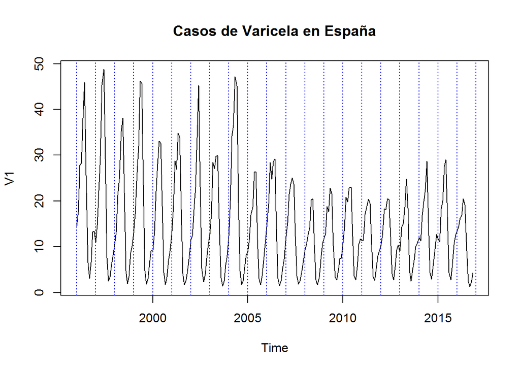

```r
plot(serie,main="Casos de Varicela en España")
abline(v=1990:2018,col=4,lty=3)
```

## Victimas

Victimas de accidentes de tráfico (fallecidos, heridos graves y leves) en vías urbanas e interurbanas en España

**Fuente**: Dirección General de Tráfico. http://www.dgt.es/es/seguridad-vial/estadisticas-e-indicadores/accidentes-30dias/series-historicas/

```r
serie=ts(read.table("victimas.dat")/1000,start=1992,freq=12)
```

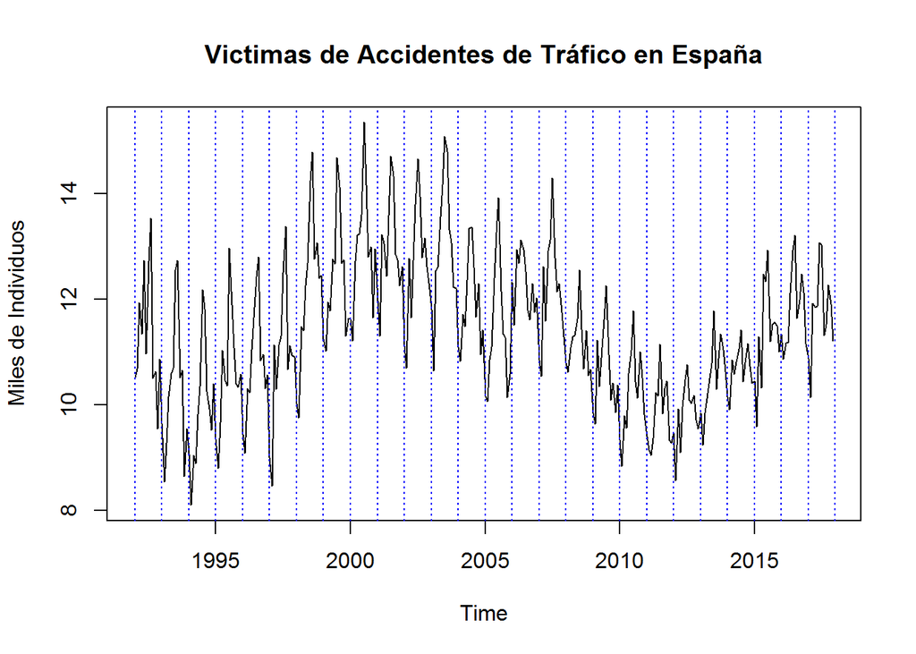

```r
plot(serie, main="Victimas de Accidentes de Tráfico en España", ylab="Miles de Individuos")
abline(v=1992:2018,lty=3,col=4)
```